# **Problem Statement**

#### **Business Context**

Understanding customer personality and behavior is pivotal for businesses to enhance customer satisfaction and increase revenue. Segmentation based on a customer's personality, demographics, and purchasing behavior allows companies to create tailored marketing campaigns, improve customer retention, and optimize product offerings.

A leading retail company with a rapidly growing customer base seeks to gain deeper insights into their customers' profiles. The company recognizes that understanding customer personalities, lifestyles, and purchasing habits can unlock significant opportunities for personalizing marketing strategies and creating loyalty programs. These insights can help address critical business challenges, such as improving the effectiveness of marketing campaigns, identifying high-value customer groups, and fostering long-term relationships with customers.

With the competition intensifying in the retail space, moving away from generic strategies to more targeted and personalized approaches is essential for sustaining a competitive edge.

#### **Objective**

In an effort to optimize marketing efficiency and enhance customer experience, the company has embarked on a mission to identify distinct customer segments. By understanding the characteristics, preferences, and behaviors of each group, the company aims to:

1. Develop personalized marketing campaigns to increase conversion rates.
2. Create effective retention strategies for high-value customers.
3. Optimize resource allocation, such as inventory management, pricing strategies, and store layouts.

As a data scientist tasked with this project, your responsibility is to analyze the given customer data, apply machine learning techniques to segment the customer base, and provide actionable insights into the characteristics of each segment.

#### **Data Dictionary**

The dataset includes historical data on customer demographics, personality traits, and purchasing behaviors. Key attributes are:

1. **Customer Information**
   - **ID:** Unique identifier for each customer.
   - **Year_Birth:** Customer's year of birth.
   - **Education:** Education level of the customer.
   - **Marital_Status:** Marital status of the customer.
   - **Income:** Yearly household income (in dollars).
   - **Kidhome:** Number of children in the household.
   - **Teenhome:** Number of teenagers in the household.
   - **Dt_Customer:** Date when the customer enrolled with the company.
   - **Recency:** Number of days since the customer’s last purchase.
   - **Complain:** Whether the customer complained in the last 2 years (1 for yes, 0 for no).
2. **Spending Information (Last 2 Years)**
   - **MntWines:** Amount spent on wine.
   - **MntFruits:** Amount spent on fruits.
   - **MntMeatProducts:** Amount spent on meat.
   - **MntFishProducts:** Amount spent on fish.
   - **MntSweetProducts:** Amount spent on sweets.
   - **MntGoldProds:** Amount spent on gold products.
3. **Purchase and Campaign Interaction**
   - **NumDealsPurchases:** Number of purchases made using a discount.
   - **AcceptedCmp1:** Response to the 1st campaign (1 for yes, 0 for no).
   - **AcceptedCmp2:** Response to the 2nd campaign (1 for yes, 0 for no).
   - **AcceptedCmp3:** Response to the 3rd campaign (1 for yes, 0 for no).
   - **AcceptedCmp4:** Response to the 4th campaign (1 for yes, 0 for no).
   - **AcceptedCmp5:** Response to the 5th campaign (1 for yes, 0 for no).
   - **Response:** Response to the last campaign (1 for yes, 0 for no).
4. **Shopping Behavior**
   - **NumWebPurchases:** Number of purchases made through the company’s website.
   - **NumCatalogPurchases:** Number of purchases made using catalogs.
   - **NumStorePurchases:** Number of purchases made directly in stores.
   - **NumWebVisitsMonth:** Number of visits to the company’s website in the last month.

# **Let's start coding!**

## **Importing necessary libraries**

```python
# Libraries to help with reading and manipulating data
import pandas as pd
import numpy as np

# libaries to help with data visualization
import matplotlib.pyplot as plt
import seaborn as sns

# Removes the limit for the number of displayed columns
pd.set_option("display.max_columns", None)
# Sets the limit for the number of displayed rows
pd.set_option("display.max_rows", 200)

# to scale the data using z-score
from sklearn.preprocessing import StandardScaler

# to compute distances
from scipy.spatial.distance import cdist, pdist

# to perform k-means clustering and compute silhouette scores
from sklearn.cluster import KMeans
from sklearn.metrics import silhouette_score

# to visualize the elbow curve and silhouette scores
from yellowbrick.cluster import KElbowVisualizer, SilhouetteVisualizer

# to suppress warnings
import warnings

warnings.filterwarnings("ignore")
```

## **Loading the data**

```python
# uncomment and run the following line if using Google Colab
# from google.colab import drive
# drive.mount('/content/drive')
```

```python
# loading data into a pandas dataframe
data = pd.read_csv("../data/Customer_Personality_Segmentation.csv", sep="\t")
```

## **Data Overview**

#### **Question 1**: What are the data types of all the columns?

```python
# Write your code here.
data.info()
```

```
<class 'pandas.core.frame.DataFrame'>
RangeIndex: 2240 entries, 0 to 2239
Data columns (total 29 columns):
 #   Column               Non-Null Count  Dtype
---  ------               --------------  -----
 0   ID                   2240 non-null   int64
 1   Year_Birth           2240 non-null   int64
 2   Education            2240 non-null   object
 3   Marital_Status       2240 non-null   object
 4   Income               2216 non-null   float64
 5   Kidhome              2240 non-null   int64
 6   Teenhome             2240 non-null   int64
 7   Dt_Customer          2240 non-null   object
 8   Recency              2240 non-null   int64
 9   MntWines             2240 non-null   int64
```

[output cut: 21 more lines]

##### **Observations:**

#### **Question 2:** Check the statistical summary of the data. What is the average household income?

```python
# Calculate average household income using Income feature
# Check if Income is already a numeric type
if data["Income"].dtype == object:
	data["Income"] = data["Income"].str.replace("[$,]", "").astype(float)
data["Income"] = data["Income"].replace(0, np.nan)
data["Income"].fillna(data["Income"].mean(), inplace=True)
print(f"Average household income: ${data['Income'].mean():.2f}")
```

```
Average household income: $52247.25
```

##### **Observations:**

#### **Question 3:** Are there any missing values in the data? If yes, treat them using an appropriate method

```python
# Check for missing values
missing_values = data.isnull().sum()
print(missing_values)
```

```
ID                     0
Year_Birth             0
Education              0
Marital_Status         0
Income                 0
Kidhome                0
Teenhome               0
Dt_Customer            0
Recency                0
MntWines               0
MntFruits              0
MntMeatProducts        0
MntFishProducts        0
MntSweetProducts       0
MntGoldProds           0
NumDealsPurchases      0
NumWebPurchases        0
NumCatalogPurchases    0
NumStorePurchases      0
NumWebVisitsMonth      0
AcceptedCmp3           0
AcceptedCmp4           0
AcceptedCmp5           0
AcceptedCmp1           0
AcceptedCmp2           0
Complain               0
Z_CostContact          0
Z_Revenue              0
Response               0
dtype: int64
```

##### **Observations:**

#### **Question 4**: Are there any duplicates in the data?

```python
# Write your code here
data.duplicated().sum()
```

```
0
```

##### **Observations:**

## **Exploratory Data Analysis**

### Univariate Analysis

#### **Question 5:** Explore all the variables and provide observations on their distributions. (histograms and boxplots)

```
===== CUSTOMER INFORMATION FEATURES =====

-------------------- Analysis for: Year_Birth --------------------
Statistics:
count    2240.000000
mean     1968.805804
std        11.984069
min      1893.000000
25%      1959.000000
50%      1970.000000
75%      1977.000000
max      1996.000000
Name: Year_Birth, dtype: float64
```

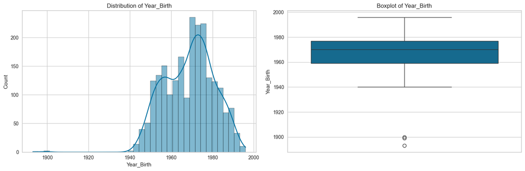

```
Skewness: -0.35
The distribution is approximately symmetric

-------------------- Analysis for: Education --------------------
Value counts:
Education
Graduation    1127
PhD            486
Master         370
2n Cycle       203
Basic           54
Name: count, dtype: int64

Percentages:
Education
Graduation    50.312500
PhD           21.696429
Master        16.517857
2n Cycle       9.062500
Basic          2.410714
Name: proportion, dtype: float64
```

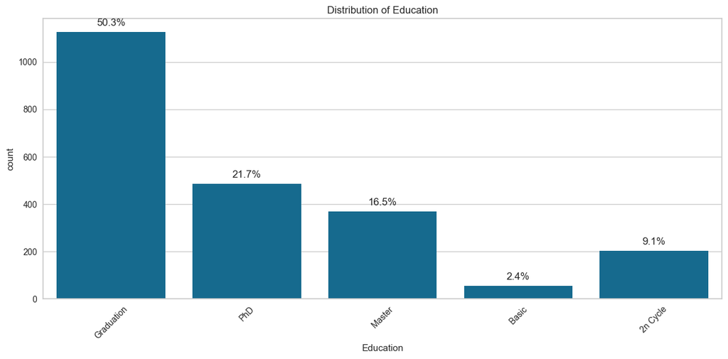

```
-------------------- Analysis for: Marital_Status --------------------
Value counts:
Marital_Status
Married     864
Together    580
Single      480
Divorced    232
Widow        77
Alone         3
Absurd        2
YOLO          2
Name: count, dtype: int64

Percentages:
Marital_Status
Married     38.571429
Together    25.892857
Single      21.428571
Divorced    10.357143
Widow        3.437500
Alone        0.133929
Absurd       0.089286
YOLO         0.089286
Name: proportion, dtype: float64
```

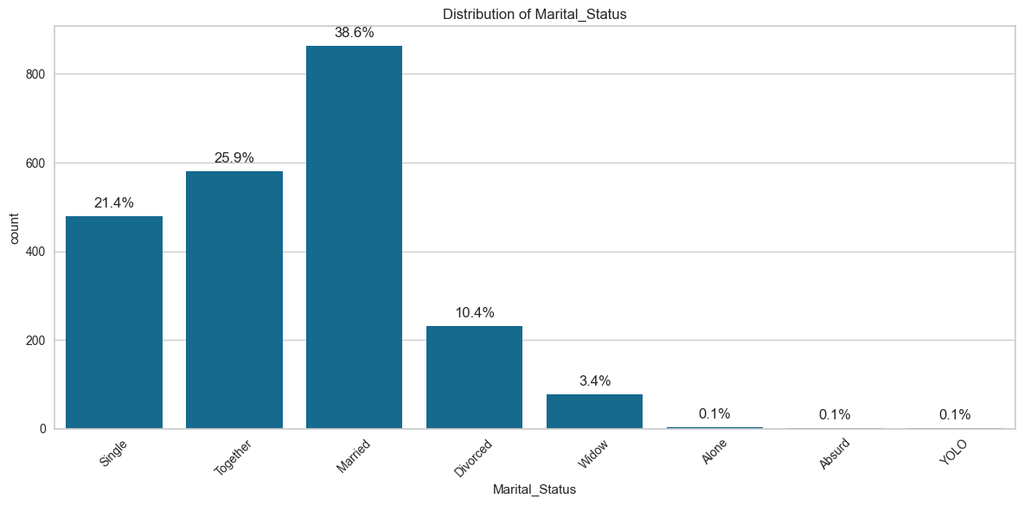

[output not shown]

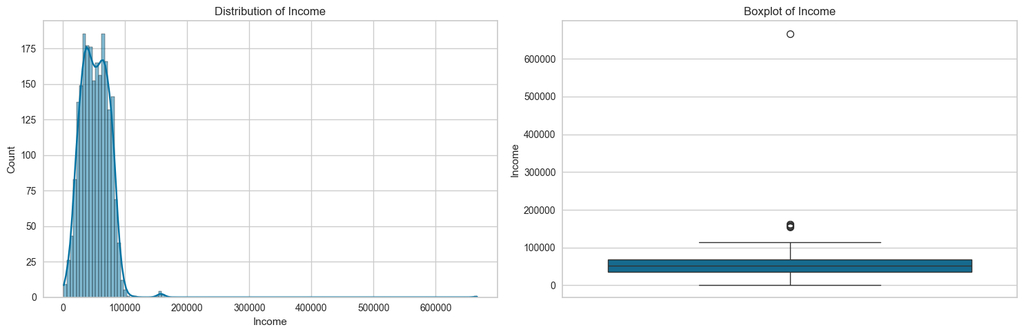

```
Skewness: 6.76
The distribution is right-skewed (positively skewed)

-------------------- Analysis for: Kidhome --------------------
Statistics:
count    2240.000000
mean        0.444196
std         0.538398
min         0.000000
25%         0.000000
50%         0.000000
75%         1.000000
max         2.000000
Name: Kidhome, dtype: float64
```

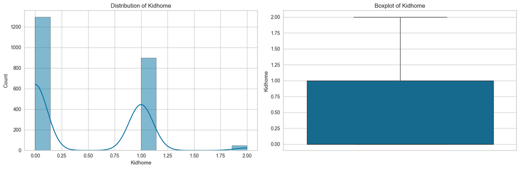

```
Skewness: 0.64
The distribution is right-skewed (positively skewed)

-------------------- Analysis for: Teenhome --------------------
Statistics:
count    2240.000000
mean        0.506250
std         0.544538
min         0.000000
25%         0.000000
50%         0.000000
75%         1.000000
max         2.000000
Name: Teenhome, dtype: float64
```

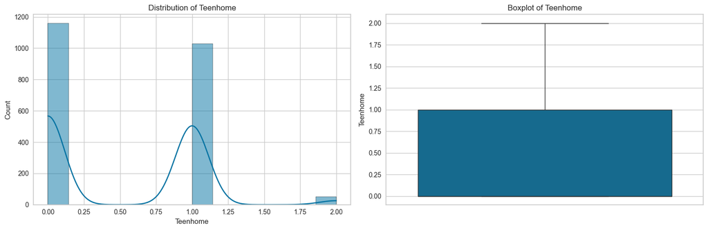

```
Skewness: 0.41
The distribution is approximately symmetric

-------------------- Analysis for: Dt_Customer --------------------
```

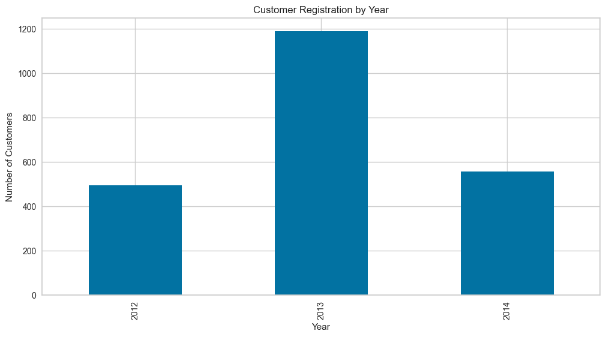

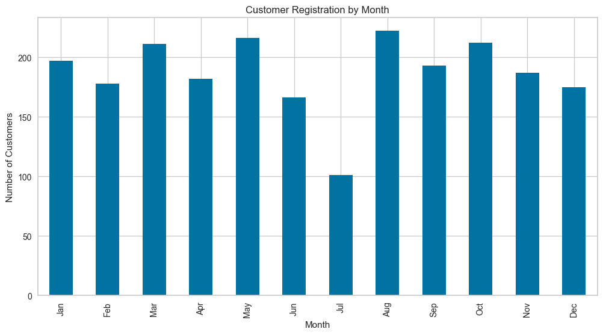

```
-------------------- Analysis for: Recency --------------------
Statistics:
count    2240.000000
mean       49.109375
std        28.962453
min         0.000000
25%        24.000000
50%        49.000000
75%        74.000000
max        99.000000
Name: Recency, dtype: float64
```

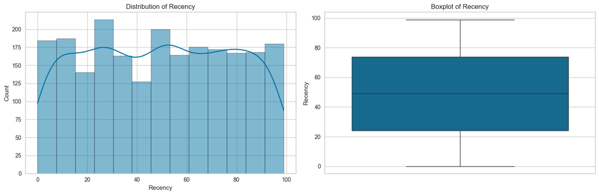

```
Skewness: -0.00
The distribution is approximately symmetric

-------------------- Analysis for: Complain --------------------
Statistics:
count    2240.000000
mean        0.009375
std         0.096391
min         0.000000
25%         0.000000
50%         0.000000
75%         0.000000
max         1.000000
Name: Complain, dtype: float64
```

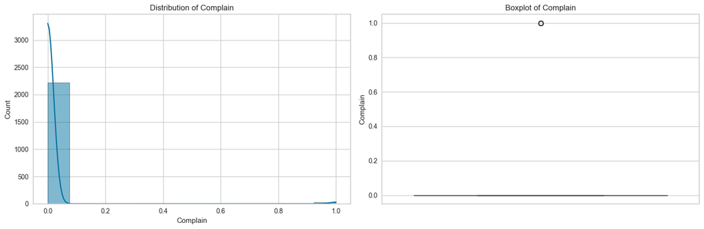

```
Skewness: 10.19
The distribution is right-skewed (positively skewed)


===== SPENDING INFORMATION FEATURES =====

-------------------- Analysis for: MntWines --------------------
Statistics:
count    2240.000000
mean      303.935714
std       336.597393
min         0.000000
25%        23.750000
50%       173.500000
75%       504.250000
max      1493.000000
Name: MntWines, dtype: float64
```

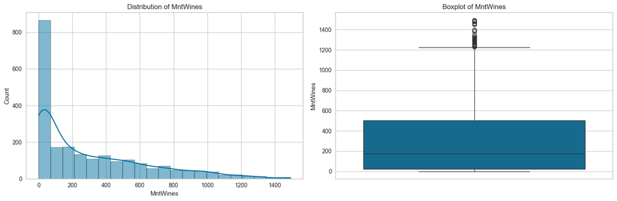

```
Skewness: 1.18
The distribution is right-skewed (positively skewed)

-------------------- Analysis for: MntFruits --------------------
Statistics:
count    2240.000000
mean       26.302232
std        39.773434
min         0.000000
25%         1.000000
50%         8.000000
75%        33.000000
max       199.000000
Name: MntFruits, dtype: float64
```

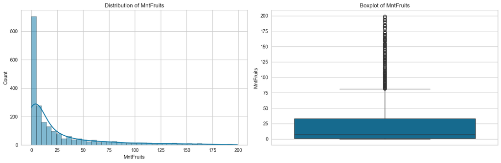

```
Skewness: 2.10
The distribution is right-skewed (positively skewed)

-------------------- Analysis for: MntMeatProducts --------------------
Statistics:
count    2240.000000
mean      166.950000
std       225.715373
min         0.000000
25%        16.000000
50%        67.000000
75%       232.000000
max      1725.000000
Name: MntMeatProducts, dtype: float64
```

[16 more figures not shown]

```
Univariate analysis complete!
```

```python
# Perform univariate analysis on all features in the dataset

# Define features by category for better organization
customer_info_features = ['Year_Birth', 'Education', 'Marital_Status', 'Income',
                          'Kidhome', 'Teenhome', 'Dt_Customer', 'Recency', 'Complain']

spending_features = ['MntWines', 'MntFruits', 'MntMeatProducts',
                    'MntFishProducts', 'MntSweetProducts', 'MntGoldProds']

campaign_features = ['NumDealsPurchases', 'AcceptedCmp1', 'AcceptedCmp2',
                    'AcceptedCmp3', 'AcceptedCmp4', 'AcceptedCmp5', 'Response']

shopping_features = ['NumWebPurchases', 'NumCatalogPurchases',
                    'NumStorePurchases', 'NumWebVisitsMonth']

# Combine all features for reference
all_features = customer_info_features + spending_features + campaign_features + shopping_features

# Add calculated age feature for better analysis
data['Age'] = 2023 - data['Year_Birth']

# Function for univariate analysis
def analyze_feature(feature):
    """Perform univariate analysis on a single feature"""
    print(f"\n{'-'*20} Analysis for: {feature} {'-'*20}")

    # Check feature type
    if data[feature].dtype in ['int64', 'float64']:
        # Numeric feature
        # Basic statistics
        stats = data[feature].describe()
        print(f"Statistics:\n{stats}")

        # Create figure with histogram and boxplot
        fig, (ax1, ax2) = plt.subplots(1, 2, figsize=(15, 5))

        # Histogram
        sns.histplot(data[feature], kde=True, ax=ax1)
        ax1.set_title(f'Distribution of {feature}')

        # Boxplot
        sns.boxplot(y=data[feature], ax=ax2)
        ax2.set_title(f'Boxplot of {feature}')

        plt.tight_layout()
        plt.show()

        # Check for skewness
        skewness = data[feature].skew()
        print(f"Skewness: {skewness:.2f}")
        if abs(skewness) < 0.5:
            print("The distribution is approximately symmetric")
        elif skewness > 0:
            print("The distribution is right-skewed (positively skewed)")
        else:
            print("The distribution is left-skewed (negatively skewed)")

    elif feature == 'Dt_Customer':
        # Date feature - special handling
        data['Dt_Customer'] = pd.to_datetime(data['Dt_Customer'], dayfirst=True)

        plt.figure(figsize=(12, 6))
        data['Dt_Customer'].dt.year.value_counts().sort_index().plot(kind='bar')
        plt.title('Customer Registration by Year')
        plt.xlabel('Year')
        plt.ylabel('Number of Customers')
        plt.show()

        plt.figure(figsize=(12, 6))
        data['Dt_Customer'].dt.month.value_counts().sort_index().plot(kind='bar')
        plt.title('Customer Registration by Month')
        plt.xlabel('Month')
        plt.ylabel('Number of Customers')
        plt.xticks(range(12), ['Jan', 'Feb', 'Mar', 'Apr', 'May', 'Jun',
                              'Jul', 'Aug', 'Sep', 'Oct', 'Nov', 'Dec'])
        plt.show()

    else:
        # Categorical feature
        value_counts = data[feature].value_counts()
        print(f"Value counts:\n{value_counts}")

        # Calculate percentages
        percentages = data[feature].value_counts(normalize=True) * 100
        print(f"\nPercentages:\n{percentages}")

        # Plot
        plt.figure(figsize=(12, 6))
        ax = sns.countplot(x=feature, data=data)
        plt.title(f'Distribution of {feature}')
        plt.xticks(rotation=45)

        # Add percentage labels
        total = len(data)
        for p in ax.patches:
            percentage = 100 * p.get_height() / total
            ax.annotate(f'{percentage:.1f}%',
                       (p.get_x() + p.get_width() / 2., p.get_height()),
                       ha = 'center', va = 'bottom',
                       xytext = (0, 5), textcoords = 'offset points')

        plt.tight_layout()
        plt.show()

# Loop through each feature category and perform analysis
print("===== CUSTOMER INFORMATION FEATURES =====")
for feature in customer_info_features:
    analyze_feature(feature)

print("\n\n===== SPENDING INFORMATION FEATURES =====")
for feature in spending_features:
    analyze_feature(feature)

print("\n\n===== CAMPAIGN INTERACTION FEATURES =====")
for feature in campaign_features:
    analyze_feature(feature)

print("\n\n===== SHOPPING BEHAVIOR FEATURES =====")
for feature in shopping_features:
    analyze_feature(feature)

# Create a correlation heatmap for numerical features
numeric_features = data.select_dtypes(include=['int64', 'float64']).columns
numeric_features = [f for f in numeric_features if f != 'ID']  # Remove ID column
plt.figure(figsize=(18, 12))
correlation = data[numeric_features].corr()
mask = np.triu(np.ones_like(correlation, dtype=bool))
sns.heatmap(correlation, annot=True, cmap='coolwarm', fmt='.2f', linewidths=0.5, mask=mask)
plt.title('Correlation Heatmap of Numeric Features', fontsize=16)
plt.xticks(rotation=45)
plt.tight_layout()
plt.show()

print("Univariate analysis complete!")
```